# Homework 11

Solutions will be available after Monday, November 9, 2026.

## Question 1: Implementing K-means

K-means is a relatively simple algorithm that we can write ourselves. For Questions 1 and 2, do not use an existing function that performs K-means directly.

Generate 10 observations with two independent standard normal coordinates. Set a random seed and report it. Randomly assign the observations to $K=2$ clusters, making sure neither cluster is empty. Let $C(i)$ denote the cluster assigned to observation $x_i$, and let $m_k$ denote the mean of cluster $k$.

1. Perform one iteration: calculate the cluster means, then assign each observation to its closest mean using Euclidean distance. Report the means and updated assignments, and plot the observations colored by their updated assignments.
2. Write a function that repeats these two steps until the assignments stop changing or a specified maximum number of iterations is reached. Your function should work for a data matrix with any number of variables and a chosen number of clusters $K$. Start from a nonempty assignment to each cluster; if a cluster becomes empty during iteration, keep its previous mean. Recalculate the cluster means from the final assignments before returning them. Return the final assignments, cluster means, and within-cluster sum of squares,

   $$\sum_{k=1}^K\sum_{i:\,C(i)=k}\lVert x_i-m_k\rVert^2.$$
3. Apply your function to the same 10 observations from two different random initial assignments. Report the final plots, cluster means, and within-cluster sums of squares. Do the two runs produce the same grouping and objective value? Explain your findings.

### My answer

I set the seed to 42 so this is reproducible. First I make the 10 points and a random $K=2$ assignment with neither cluster empty.

```python
import numpy as np
import matplotlib.pyplot as plt

np.random.seed(42)
X = np.random.randn(10, 2)

K = 2
while True:
    init = np.random.randint(0, K, size=X.shape[0])
    if len(np.unique(init)) == K:
        break
init
```

```
array([1, 1, 0, 1, 0, 1, 0, 1, 1, 0])
```

**(a)** One iteration is just: compute the cluster means from the current assignment, then reassign each point to its nearest mean.

```python
def cluster_means(X, assign, K):
    return np.array([X[assign == k].mean(axis=0) for k in range(K)])

m = cluster_means(X, init, K)
dist = np.linalg.norm(X[:, None, :] - m[None, :, :], axis=2)
updated = dist.argmin(axis=1)

print("cluster means:\n", np.round(m, 3))
print("updated assignments:", updated)
```

```
cluster means:
 [[-0.342 -0.754]
 [-0.08   0.24 ]]
updated assignments: [1 1 1 1 1 0 0 0 1 0]
```

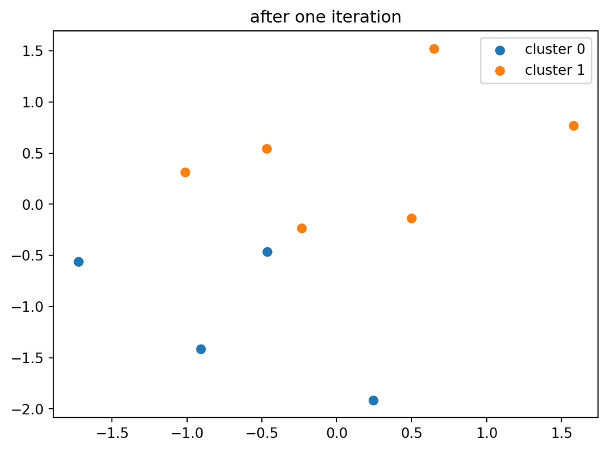

```python
for k in range(K):
    pts = X[updated == k]
    plt.scatter(pts[:, 0], pts[:, 1], label=f"cluster {k}")
plt.legend(); plt.title("after one iteration"); plt.show()
```

**(b)** The function keeps alternating the two steps until nothing changes or it hits the cap. It works for any number of variables and any $K$, and if a cluster empties out partway through it just hangs onto that cluster’s previous mean.

```python
def my_kmeans(X, K, init_assign, max_iter=100):
    X = np.asarray(X, float)
    assign = np.asarray(init_assign).copy()
    means = np.array([X[assign == k].mean(axis=0) for k in range(K)])
    for _ in range(max_iter):
        for k in range(K):
            if np.any(assign == k):
                means[k] = X[assign == k].mean(axis=0)
        dist = np.linalg.norm(X[:, None, :] - means[None, :, :], axis=2)
        new = dist.argmin(axis=1)
        if np.array_equal(new, assign):
            break
        assign = new
    means = np.array([X[assign == k].mean(axis=0) if np.any(assign == k) else means[k]
                      for k in range(K)])
    wcss = sum(((X[assign == k] - means[k]) ** 2).sum() for k in range(K))
    return assign, means, wcss
```

**(c)** Running it from two different random starts on the same 10 points:

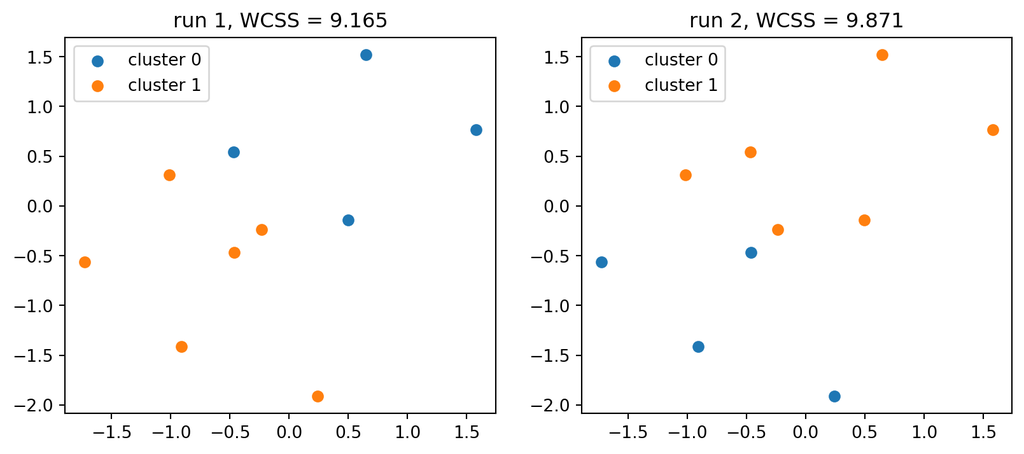

```
run 1: WCSS = 9.1652
  means:
 [[ 0.564  0.674]
 [-0.684 -0.712]]
run 2: WCSS = 9.8706
  means:
 [[-0.714 -1.088]
 [ 0.168  0.462]]
```

```python
runs = []
for i in range(2):
    while True:
        ia = np.random.randint(0, K, size=X.shape[0])
        if len(np.unique(ia)) == K:
            break
    asg, mns, w = my_kmeans(X, K, ia)
    runs.append((asg, mns, w))

fig, ax = plt.subplots(1, 2, figsize=(10, 4))
for i, (asg, mns, w) in enumerate(runs):
    for k in range(K):
        pts = X[asg == k]
        ax[i].scatter(pts[:, 0], pts[:, 1], label=f"cluster {k}")
    ax[i].set_title(f"run {i+1}, WCSS = {w:.3f}")
    ax[i].legend()
plt.show()

for i, (asg, mns, w) in enumerate(runs):
    print(f"run {i+1}: WCSS = {w:.4f}")
    print("  means:\n", np.round(mns, 3))
```

The two runs don’t always give the same thing. K-means only converges to a local minimum of the WCSS, not necessarily the global one, so the starting assignment matters. Depending on the random inits the runs can end up with different groupings and different WCSS values. That’s the whole reason people usually run it a bunch of times from different starts and keep whichever gives the lowest WCSS.

## Question 2: Image color compression

Pick your favorite color image and use your K-means function from Question 1 to cluster its pixels. For computational efficiency, resize the image to no more than $200\times200$ pixels and use its three RGB color channels.

1. Plot the original image and report its dimensions. Transform it into a data matrix with one observation per pixel and three variables: red, green, and blue. Report the dimensions of this matrix.
2. For $K=2,3,5,10$, apply your function to the pixel data. Report the cluster means and within-cluster sum of squares for each $K$. Reconstruct and plot each compressed image by replacing every pixel with its assigned cluster mean. Use the same RGB scale for all fits.
3. Which value of $K$ would you choose for this image? Briefly justify your choice using the reconstructed images and the within-cluster sums of squares.

### My answer

I grabbed a sample color photo (the coffee cup that ships with scikit-image) since it’s got a decent spread of colors to compress.

**(a)**

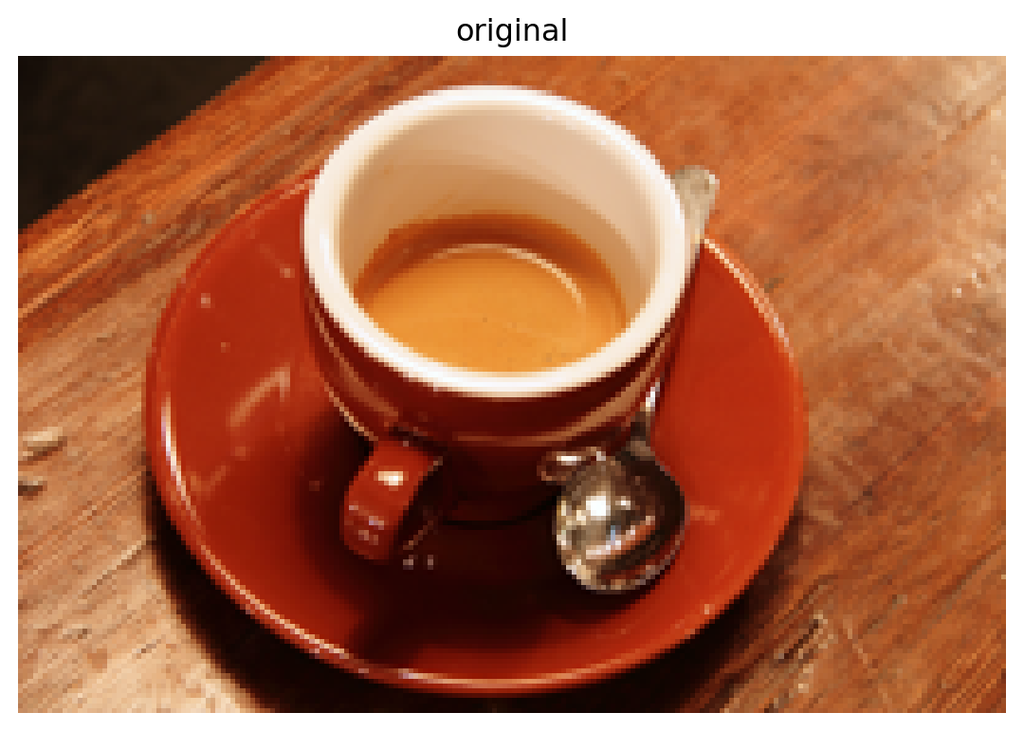

```
image dimensions: (133, 200, 3)
pixel data matrix: (26600, 3)
```

```python
from skimage import data
from PIL import Image

img = Image.fromarray(data.coffee())
img.thumbnail((200, 200))
arr = np.asarray(img)

plt.imshow(arr); plt.axis("off"); plt.title("original"); plt.show()
print("image dimensions:", arr.shape)

pixels = arr.reshape(-1, 3).astype(float)
print("pixel data matrix:", pixels.shape)
```

After resizing the image is 133x200x3, so the pixel matrix is 26600x3: one row per pixel, with columns for red, green, and blue.

**(b)**

```python
np.random.seed(7)
Ks = [2, 3, 5, 10]
fits = {}
for Kc in Ks:
    while True:
        ia = np.random.randint(0, Kc, size=pixels.shape[0])
        if len(np.unique(ia)) == Kc:
            break
    asg, mns, w = my_kmeans(pixels, Kc, ia, max_iter=50)
    fits[Kc] = (asg, mns, w)
    print(f"K={Kc}: WCSS = {w:,.0f}")
    print("  cluster means (RGB):\n", np.round(mns, 1))
```

```
K=2: WCSS = 118,244,938
  cluster means (RGB):
 [[203.  135.6  88.2]
 [115.9  38.   16.3]]
K=3: WCSS = 57,229,736
  cluster means (RGB):
 [[178.5  86.3  42.7]
 [ 59.8  14.7   6.7]
 [223.1 179.7 141.8]]
K=5: WCSS = 22,354,906
  cluster means (RGB):
 [[183.1  99.9  51. ]
 [209.6 145.   91.9]
 [237.9 213.3 188.8]
 [ 48.6  12.2   5.9]
 [157.1  49.5  20. ]]
K=10: WCSS = 9,499,647
  cluster means (RGB):
 [[246.3 233.6 219.5]
 [190.4 106.   53.8]
 [171.2  44.2  15.5]
 [103.8  22.9   9.3]
 [224.4 181.9 142.7]
 [171.6  84.7  39.5]
 [ 37.9  10.3   5.2]
 [196.  125.6  76.6]
 [214.6 147.9  88.9]
 [143.1  65.4  31.9]]
```

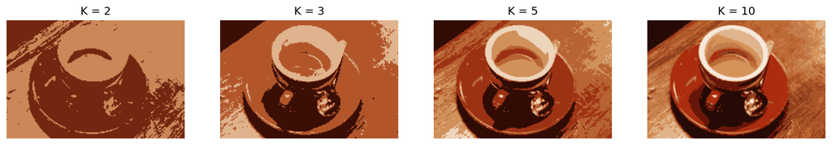

```python
fig, ax = plt.subplots(1, 4, figsize=(16, 5))
for i, Kc in enumerate(Ks):
    asg, mns, w = fits[Kc]
    recon = mns[asg].reshape(arr.shape).clip(0, 255).astype(np.uint8)
    ax[i].imshow(recon)
    ax[i].axis("off")
    ax[i].set_title(f"K = {Kc}")
plt.show()
```

**(c)** WCSS keeps dropping as $K$ goes up, which has to happen since more colors can only fit the pixels better. But the gains shrink fast. Going 2 to 3 to 5 makes a big visible difference, and by $K=5$ the picture already looks close to the original. $K=10$ lowers WCSS more but the visual improvement over 5 is pretty marginal. I’d pick $K=5$: it captures the main colors well and still cuts the palette way down from the original.

## Question 3: Hierarchical clustering of cars

The file `data/mtcars.csv` contains 11 numerical variables for 32 cars, including fuel economy, horsepower, and weight. The `car` column gives the model names; use it to label observations, not as a clustering variable. You may use existing hierarchical clustering functions for this question.

1. Standardize each numerical variable to have mean 0 and standard deviation 1. Using Euclidean distance, perform hierarchical clustering with single, complete, and average linkage. Plot the three dendrograms with the car names and compare the results.
2. Choose one linkage method and a number of clusters that you consider reasonable. Report the cluster memberships and a table of cluster means on the original variable scales. Describe the main characteristics of the groups and explain your choice using the dendrogram and table. Briefly explain why standardizing the variables matters for this analysis.

### My answer

**(a)** Standardize every numeric column, then run the three linkages on Euclidean distance.

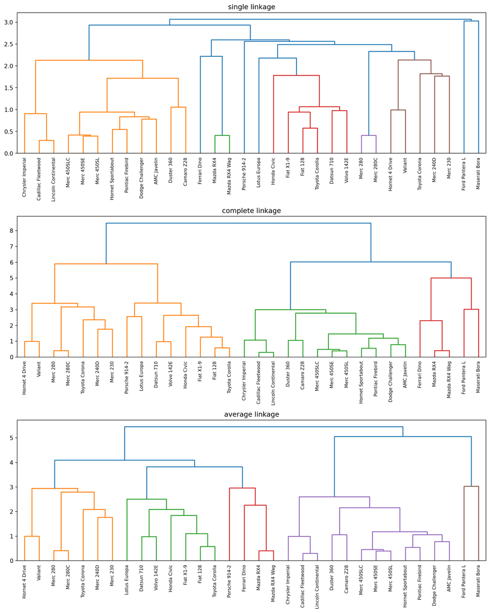

```python
import pandas as pd
from scipy.cluster.hierarchy import linkage, dendrogram, fcluster
from scipy.spatial.distance import pdist

cars = pd.read_csv("data/mtcars.csv")
names = cars["car"].values
Xnum = cars.drop(columns=["car"])

Xs = (Xnum - Xnum.mean()) / Xnum.std(ddof=1)
d = pdist(Xs.values, metric="euclidean")

fig, ax = plt.subplots(3, 1, figsize=(12, 15))
for a, meth in zip(ax, ["single", "complete", "average"]):
    Z = linkage(d, method=meth)
    dendrogram(Z, labels=names, leaf_rotation=90, leaf_font_size=8, ax=a)
    a.set_title(f"{meth} linkage")
plt.tight_layout(); plt.show()
```

Single linkage chains the points together into one lopsided tree with lots of near-ties, so it’s hard to read off clean groups. Complete and average both give more balanced trees with clearer separation. Complete gives the most distinct, compact clusters, so that’s the one I’ll use.

**(b)** Going with complete linkage cut at 4 clusters, since that’s where the tree shows clearly separated branches.

```python
Z = linkage(d, method="complete")
clust = fcluster(Z, t=4, criterion="maxclust")

for c in range(1, 5):
    print(f"cluster {c}:", list(names[clust == c]))

means = Xnum.groupby(clust).mean().round(2)
means.index.name = "cluster"
means
```

```
cluster 1: ['Hornet 4 Drive', 'Valiant', 'Merc 240D', 'Merc 230', 'Merc 280', 'Merc 280C', 'Toyota Corona']
cluster 2: ['Datsun 710', 'Fiat 128', 'Honda Civic', 'Toyota Corolla', 'Fiat X1-9', 'Porsche 914-2', 'Lotus Europa', 'Volvo 142E']
cluster 3: ['Hornet Sportabout', 'Duster 360', 'Merc 450SE', 'Merc 450SL', 'Merc 450SLC', 'Cadillac Fleetwood', 'Lincoln Continental', 'Chrysler Imperial', 'Dodge Challenger', 'AMC Javelin', 'Camaro Z28', 'Pontiac Firebird']
cluster 4: ['Mazda RX4', 'Mazda RX4 Wag', 'Ford Pantera L', 'Ferrari Dino', 'Maserati Bora']
```

| cluster | mpg | cyl | disp | hp | drat | wt | qsec | vs | am | gear | carb |
| --- | --- | --- | --- | --- | --- | --- | --- | --- | --- | --- | --- |
| 1 | 20.74 | 5.14 | 175.11 | 102.14 | 3.57 | 3.19 | 19.97 | 1.00 | 0.0 | 3.57 | 2.14 |
| 2 | 28.08 | 4.00 | 93.61 | 81.88 | 4.18 | 2.04 | 18.45 | 0.88 | 1.0 | 4.25 | 1.50 |
| 3 | 15.05 | 8.00 | 357.62 | 194.17 | 3.12 | 4.10 | 17.14 | 0.00 | 0.0 | 3.00 | 3.08 |
| 4 | 18.50 | 6.80 | 223.40 | 198.80 | 3.84 | 3.00 | 15.62 | 0.00 | 1.0 | 4.60 | 5.20 |

The groups line up with car types pretty cleanly:

- Economy cars (Civic, Corolla, the Fiats, Lotus): 4 cylinders, high mpg, light, mostly manual.
- Mid-size sedans (smaller Mercs, Hornet 4 Drive, Valiant, Corona): moderate everything, around 6 cylinders, slower (high qsec), automatic.
- Big V8 muscle and luxury (Cadillac, Lincoln, Chrysler, Camaro, the big Mercs): 8 cylinders, huge displacement, heavy, low mpg.
- Sporty high-performance (Maserati Bora, Ferrari Dino, Pantera, Mazda RX4s): lots of horsepower and carburetors, quick, manual.

Standardizing matters because the variables are on totally different scales. Displacement and horsepower run into the hundreds, while `vs`, `am`, and `drat` are tiny by comparison. Euclidean distance would be almost entirely driven by displacement and horsepower if I left things raw, and the small-scale variables would basically get ignored. Rescaling everything to mean 0 and sd 1 lets each variable pull its weight equally.